# IST 387 HW 7

##### Copyright 2021, Jeffrey Stanton, Jeffrey Saltz, and Jasmina Tacheva

```r
# Enter your name here: Ezra Cohen
```

### Attribution statement: (choose only one and delete the rest)

```r
# 1. I did this homework by myself, with help from the book and the professor.
```

**Chapter 13 of Introduction to Data Science**

**This module:** Last module we explored **data visualization** in R using the **ggplot2** package. This module continues to use ggplot, together with a companion package called **ggmap**. This package enhances the capabilities of ggplot by adding the capability to **draw geographic outlines (polygons), shading, labeling, and other map markings**. In addition, we will merge datasets using the built-in **merge( )** function, which provides a similar capability to a **JOIN in SQL**. Many analytical strategies require joining data from different sources based on a **“key”** – a field that two datasets have in common.

## Step 1: Load the population data

A. The following lines of code will help you read a json file into an R dataframe. Examine the resulting pop dataframe with View() and add comments explaining what each column contains.

```r
library(jsonlite)
url="https://ist387.s3.us-east-2.amazonaws.com/data/cities.json"
pop <- jsonlite::fromJSON(url)
pop
#city says the name of city, growth_from_2000_to_2013 says the % increase or decrease of the population from 2000 to 2013, latitude says latitude,longitude says longitude, population says the population,rank seems to just have their index,state says the state the city is located in
```

A data.frame: 1000 × 7

|  | city <chr> | growth_from_2000_to_2013 <chr> | latitude <dbl> | longitude <dbl> | population <chr> | rank <chr> | state <chr> |
| --- | --- | --- | --- | --- | --- | --- | --- |
| 1 | New York | 4.8% | 40.71278 | -74.00594 | 8405837 | 1 | New York |
| 2 | Los Angeles | 4.8% | 34.05223 | -118.24368 | 3884307 | 2 | California |
| 3 | Chicago | -6.1% | 41.87811 | -87.62980 | 2718782 | 3 | Illinois |
| 4 | Houston | 11.0% | 29.76043 | -95.36980 | 2195914 | 4 | Texas |
| 5 | Philadelphia | 2.6% | 39.95258 | -75.16522 | 1553165 | 5 | Pennsylvania |
| 6 | Phoenix | 14.0% | 33.44838 | -112.07404 | 1513367 | 6 | Arizona |
| 7 | San Antonio | 21.0% | 29.42412 | -98.49363 | 1409019 | 7 | Texas |
| 8 | San Diego | 10.5% | 32.71574 | -117.16108 | 1355896 | 8 | California |
| 9 | Dallas | 5.6% | 32.77666 | -96.79699 | 1257676 | 9 | Texas |
| 10 | San Jose | 10.5% | 37.33821 | -121.88633 | 998537 | 10 | California |
| 11 | Austin | 31.7% | 30.26715 | -97.74306 | 885400 | 11 | Texas |
| 12 | Indianapolis | 7.8% | 39.76840 | -86.15807 | 843393 | 12 | Indiana |
| 13 | Jacksonville | 14.3% | 30.33218 | -81.65565 | 842583 | 13 | Florida |
| 14 | San Francisco | 7.7% | 37.77493 | -122.41942 | 837442 | 14 | California |
| 15 | Columbus | 14.8% | 39.96118 | -82.99879 | 822553 | 15 | Ohio |
| 16 | Charlotte | 39.1% | 35.22709 | -80.84313 | 792862 | 16 | North Carolina |
| 17 | Fort Worth | 45.1% | 32.75549 | -97.33077 | 792727 | 17 | Texas |
| 18 | Detroit | -27.1% | 42.33143 | -83.04575 | 688701 | 18 | Michigan |
| 19 | El Paso | 19.4% | 31.77758 | -106.44246 | 674433 | 19 | Texas |
| 20 | Memphis | -5.3% | 35.14953 | -90.04898 | 653450 | 20 | Tennessee |
| 21 | Seattle | 15.6% | 47.60621 | -122.33207 | 652405 | 21 | Washington |
| 22 | Denver | 16.7% | 39.73924 | -104.99025 | 649495 | 22 | Colorado |
| 23 | Washington | 13.0% | 38.90719 | -77.03687 | 646449 | 23 | District of Columbia |
| 24 | Boston | 9.4% | 42.36008 | -71.05888 | 645966 | 24 | Massachusetts |
| 25 | Nashville-Davidson | 16.2% | 36.16266 | -86.78160 | 634464 | 25 | Tennessee |
| 26 | Baltimore | -4.0% | 39.29038 | -76.61219 | 622104 | 26 | Maryland |
| 27 | Oklahoma City | 20.2% | 35.46756 | -97.51643 | 610613 | 27 | Oklahoma |
| 28 | Louisville/Jefferson County | 10.0% | 38.25266 | -85.75846 | 609893 | 28 | Kentucky |
| 29 | Portland | 15.0% | 45.52306 | -122.67648 | 609456 | 29 | Oregon |
| 30 | Las Vegas | 24.5% | 36.16994 | -115.13983 | 603488 | 30 | Nevada |
| ⋮ | ⋮ | ⋮ | ⋮ | ⋮ | ⋮ | ⋮ | ⋮ |
| 971 | Brookfield | -1.9% | 43.06057 | -88.10648 | 37999 | 971 | Wisconsin |
| 972 | Park Ridge | 0.1% | 42.01114 | -87.84062 | 37839 | 972 | Illinois |
| 973 | Florence | 19.8% | 34.19543 | -79.76256 | 37792 | 973 | South Carolina |
| 974 | Roy | 13.3% | 41.16161 | -112.02633 | 37733 | 974 | Utah |
| 975 | Winter Garden | 142.5% | 28.56528 | -81.58618 | 37711 | 975 | Florida |
| 976 | Chelsea | 7.3% | 42.39176 | -71.03283 | 37670 | 976 | Massachusetts |
| 977 | Valley Stream | 3.6% | 40.66427 | -73.70846 | 37659 | 977 | New York |
| 978 | Spartanburg | -6.2% | 34.94957 | -81.93205 | 37647 | 978 | South Carolina |
| 979 | Lake Oswego | 5.3% | 45.42067 | -122.67065 | 37610 | 979 | Oregon |
| 980 | Friendswood | 28.6% | 29.52940 | -95.20104 | 37587 | 980 | Texas |
| 981 | Westerville | 5.7% | 40.12617 | -82.92907 | 37530 | 981 | Ohio |
| 982 | Northglenn | 15.5% | 39.89618 | -104.98115 | 37499 | 982 | Colorado |
| 983 | Phenix City | 31.9% | 32.47098 | -85.00077 | 37498 | 983 | Alabama |
| 984 | Grove City | 35.6% | 39.88145 | -83.09296 | 37490 | 984 | Ohio |
| 985 | Texarkana | 7.4% | 33.42513 | -94.04769 | 37442 | 985 | Texas |
| 986 | Addison | 2.6% | 41.93170 | -87.98896 | 37385 | 986 | Illinois |
| 987 | Dover | 16.0% | 39.15817 | -75.52437 | 37366 | 987 | Delaware |
| 988 | Lincoln Park | -6.7% | 42.25059 | -83.17854 | 37313 | 988 | Michigan |
| 989 | Calumet City | -4.5% | 41.61559 | -87.52949 | 37240 | 989 | Illinois |
| 990 | Muskegon | -7.1% | 43.23418 | -86.24839 | 37213 | 990 | Michigan |
| 991 | Aventura | 47.2% | 25.95648 | -80.13921 | 37199 | 991 | Florida |
| 992 | Martinez | 3.4% | 38.01937 | -122.13413 | 37165 | 992 | California |
| 993 | Greenfield | 4.8% | 42.96140 | -88.01259 | 37159 | 993 | Wisconsin |
| 994 | Apache Junction | 15.7% | 33.41505 | -111.54958 | 37130 | 994 | Arizona |
| 995 | Monrovia | 0.2% | 34.14426 | -118.00195 | 37101 | 995 | California |
| 996 | Weslaco | 28.8% | 26.15952 | -97.99084 | 37093 | 996 | Texas |
| 997 | Keizer | 14.4% | 44.99012 | -123.02621 | 37064 | 997 | Oregon |
| 998 | Spanish Fork | 78.1% | 40.11496 | -111.65492 | 36956 | 998 | Utah |
| 999 | Beloit | 2.9% | 42.50835 | -89.03178 | 36888 | 999 | Wisconsin |
| 1000 | Panama City | 0.1% | 30.15881 | -85.66021 | 36877 | 1000 | Florida |

B. Calculate the **average population** in the dataframe. Why is using mean() directly not working? Find a way to correct the data type of this variable so you can calculate the average.

```r
mean(as.numeric(pop$population))
#it wouldn't work directly because it's mode is character not numeric
```

131132.443

C. What is the population of the smallest city in the dataframe? Which state is it in?

```r
min(as.numeric(pop$population))
pop$state[which.min(as.numeric(pop$population))]
```

36877

'Florida'

## Step 2: Merge the population data with the state name data

D) Read in the state name .csv file from the URL below into a dataframe named **abbr** (for "abbreviation") – make sure to use the read_csv() function from the tidyverse package:  
https://ist387.s3.us-east-2.amazonaws.com/data/states.csv

```r
library(tidyverse)
abbr<-data.frame(read_csv("https://ist387.s3.us-east-2.amazonaws.com/data/states.csv"))
abbr
```

A data.frame: 51 × 2

| State <chr> | Abbreviation <chr> |
| --- | --- |
| Alabama | AL |
| Alaska | AK |
| Arizona | AZ |
| Arkansas | AR |
| California | CA |
| Colorado | CO |
| Connecticut | CT |
| Delaware | DE |
| District of Columbia | DC |
| Florida | FL |
| Georgia | GA |
| Hawaii | HI |
| Idaho | ID |
| Illinois | IL |
| Indiana | IN |
| Iowa | IA |
| Kansas | KS |
| Kentucky | KY |
| Louisiana | LA |
| Maine | ME |
| Montana | MT |
| Nebraska | NE |
| Nevada | NV |
| New Hampshire | NH |
| New Jersey | NJ |
| New Mexico | NM |
| New York | NY |
| North Carolina | NC |
| North Dakota | ND |
| Ohio | OH |
| Oklahoma | OK |
| Oregon | OR |
| Maryland | MD |
| Massachusetts | MA |
| Michigan | MI |
| Minnesota | MN |
| Mississippi | MS |
| Missouri | MO |
| Pennsylvania | PA |
| Rhode Island | RI |
| South Carolina | SC |
| South Dakota | SD |
| Tennessee | TN |
| Texas | TX |
| Utah | UT |
| Vermont | VT |
| Virginia | VA |
| Washington | WA |
| West Virginia | WV |
| Wisconsin | WI |
| Wyoming | WY |

E) To successfully merge the dataframe **pop** with the **abbr** dataframe, we need to identify a **column they have in common** which will serve as the **“key”** to merge on. One column both dataframes have is the **state column**. The only problem is the slight column name discrepancy – in **pop**, the column is called **“state”** and in **abbr** – **“State.”** These names need to be reconciled for the merge() function to work. Find a way to rename **abbr’s “State”** to **match** the **state column in pop**.

```r
abbr$state<-abbr$State
```

F) Merge the two dataframes (using the **‘state’ column** from both dataframes), storing the resulting dataframe in **dfNew**.

```r
dfNew<-merge(pop,abbr)
dfNew
```

A data.frame: 1000 × 9

| state <chr> | city <chr> | growth_from_2000_to_2013 <chr> | latitude <dbl> | longitude <dbl> | population <chr> | rank <chr> | State <chr> | Abbreviation <chr> |
| --- | --- | --- | --- | --- | --- | --- | --- | --- |
| Alabama | Auburn | 26.4% | 32.60986 | -85.48078 | 58582 | 615 | Alabama | AL |
| Alabama | Florence | 10.2% | 34.79981 | -87.67725 | 40059 | 922 | Alabama | AL |
| Alabama | Huntsville | 16.3% | 34.73037 | -86.58610 | 186254 | 126 | Alabama | AL |
| Alabama | Dothan | 16.6% | 31.22323 | -85.39049 | 68001 | 502 | Alabama | AL |
| Alabama | Birmingham | -12.3% | 33.52066 | -86.80249 | 212113 | 101 | Alabama | AL |
| Alabama | Phenix City | 31.9% | 32.47098 | -85.00077 | 37498 | 983 | Alabama | AL |
| Alabama | Hoover | 32.7% | 33.40539 | -86.81138 | 84126 | 376 | Alabama | AL |
| Alabama | Decatur | 3.1% | 34.60593 | -86.98334 | 55816 | 653 | Alabama | AL |
| Alabama | Mobile | -1.9% | 30.69537 | -88.03989 | 194899 | 122 | Alabama | AL |
| Alabama | Montgomery | -0.1% | 32.36681 | -86.29997 | 201332 | 111 | Alabama | AL |
| Alabama | Madison | 53.7% | 34.69926 | -86.74833 | 45799 | 811 | Alabama | AL |
| Alabama | Tuscaloosa | 21.1% | 33.20984 | -87.56917 | 95334 | 313 | Alabama | AL |
| Alaska | Anchorage | 15.4% | 61.21806 | -149.90028 | 300950 | 63 | Alaska | AK |
| Arizona | Scottsdale | 11.0% | 33.49417 | -111.92605 | 226918 | 95 | Arizona | AZ |
| Arizona | Prescott | 18.1% | 34.54002 | -112.46850 | 40590 | 907 | Arizona | AZ |
| Arizona | Peoria | 46.5% | 33.58060 | -112.23738 | 162592 | 149 | Arizona | AZ |
| Arizona | Gilbert | 96.0% | 33.35283 | -111.78903 | 229972 | 92 | Arizona | AZ |
| Arizona | Chandler | 38.7% | 33.30616 | -111.84125 | 249146 | 79 | Arizona | AZ |
| Arizona | Buckeye | 480.9% | 33.37032 | -112.58378 | 56683 | 641 | Arizona | AZ |
| Arizona | Prescott Valley | 62.9% | 34.61002 | -112.31572 | 39791 | 929 | Arizona | AZ |
| Arizona | Surprise | 281.9% | 33.62923 | -112.36793 | 123546 | 216 | Arizona | AZ |
| Arizona | Apache Junction | 15.7% | 33.41505 | -111.54958 | 37130 | 994 | Arizona | AZ |
| Arizona | Sierra Vista | 19.3% | 31.54550 | -110.27729 | 45129 | 823 | Arizona | AZ |
| Arizona | Casa Grande | 86.0% | 32.87950 | -111.75735 | 50111 | 743 | Arizona | AZ |
| Arizona | Bullhead City | 15.9% | 35.13594 | -114.52860 | 39383 | 941 | Arizona | AZ |
| Arizona | Mesa | 13.5% | 33.41518 | -111.83147 | 457587 | 38 | Arizona | AZ |
| Arizona | Oro Valley | 27.0% | 32.39091 | -110.96649 | 41627 | 883 | Arizona | AZ |
| Arizona | Yuma | 16.2% | 32.69265 | -114.62769 | 91923 | 330 | Arizona | AZ |
| Arizona | Marana | 166.2% | 32.43638 | -111.22244 | 38290 | 964 | Arizona | AZ |
| Arizona | Goodyear | 271.0% | 33.43534 | -112.35766 | 72864 | 462 | Arizona | AZ |
| ⋮ | ⋮ | ⋮ | ⋮ | ⋮ | ⋮ | ⋮ | ⋮ | ⋮ |
| Washington | Spokane | 7.0% | 47.65878 | -117.42605 | 210721 | 102 | Washington | WA |
| Washington | Pasco | 98.5% | 46.23958 | -119.10057 | 67599 | 506 | Washington | WA |
| Washington | Bellingham | 21.8% | 48.74908 | -122.47815 | 82631 | 390 | Washington | WA |
| Washington | Kennewick | 29.1% | 46.21125 | -119.13723 | 76762 | 432 | Washington | WA |
| Washington | Redmond | 26.0% | 47.67399 | -122.12151 | 57530 | 627 | Washington | WA |
| Washington | Shoreline | 2.9% | 47.75565 | -122.34152 | 54790 | 668 | Washington | WA |
| West Virginia | Charleston | -4.7% | 38.34982 | -81.63262 | 50821 | 725 | West Virginia | WV |
| West Virginia | Huntington | -5.0% | 38.41925 | -82.44515 | 49177 | 760 | West Virginia | WV |
| Wisconsin | Greenfield | 4.8% | 42.96140 | -88.01259 | 37159 | 993 | Wisconsin | WI |
| Wisconsin | Madison | 15.8% | 43.07305 | -89.40123 | 243344 | 83 | Wisconsin | WI |
| Wisconsin | West Allis | -0.6% | 43.01668 | -88.00703 | 60697 | 582 | Wisconsin | WI |
| Wisconsin | Waukesha | 8.0% | 43.01168 | -88.23148 | 71016 | 475 | Wisconsin | WI |
| Wisconsin | Beloit | 2.9% | 42.50835 | -89.03178 | 36888 | 999 | Wisconsin | WI |
| Wisconsin | La Crosse | -0.8% | 43.80136 | -91.23958 | 51522 | 716 | Wisconsin | WI |
| Wisconsin | Brookfield | -1.9% | 43.06057 | -88.10648 | 37999 | 971 | Wisconsin | WI |
| Wisconsin | Fond du Lac | 1.7% | 43.77304 | -88.44705 | 42970 | 857 | Wisconsin | WI |
| Wisconsin | Eau Claire | 8.7% | 44.81135 | -91.49849 | 67545 | 508 | Wisconsin | WI |
| Wisconsin | Racine | -4.4% | 42.72613 | -87.78285 | 78199 | 421 | Wisconsin | WI |
| Wisconsin | Appleton | 4.5% | 44.26193 | -88.41538 | 73596 | 456 | Wisconsin | WI |
| Wisconsin | Oshkosh | 5.3% | 44.02471 | -88.54261 | 66778 | 515 | Wisconsin | WI |
| Wisconsin | Wauwatosa | 0.0% | 43.04946 | -88.00759 | 47134 | 795 | Wisconsin | WI |
| Wisconsin | Sheboygan | -3.9% | 43.75083 | -87.71453 | 48725 | 766 | Wisconsin | WI |
| Wisconsin | Wausau | 1.7% | 44.95914 | -89.63012 | 39309 | 945 | Wisconsin | WI |
| Wisconsin | Janesville | 5.6% | 42.68279 | -89.01872 | 63820 | 545 | Wisconsin | WI |
| Wisconsin | Milwaukee | 0.3% | 43.03890 | -87.90647 | 599164 | 31 | Wisconsin | WI |
| Wisconsin | Kenosha | 9.5% | 42.58474 | -87.82119 | 99889 | 294 | Wisconsin | WI |
| Wisconsin | Green Bay | 1.9% | 44.51916 | -88.01983 | 104779 | 272 | Wisconsin | WI |
| Wisconsin | New Berlin | 3.6% | 42.97640 | -88.10842 | 39834 | 926 | Wisconsin | WI |
| Wyoming | Cheyenne | 16.9% | 41.13998 | -104.82025 | 62448 | 558 | Wyoming | WY |
| Wyoming | Casper | 19.9% | 42.86663 | -106.31308 | 59628 | 599 | Wyoming | WY |

G) Review the structure of **dfNew** and explain the columns (aka attributes) in that dataframe.

```r
str(dfNew)
#city says the name of city, growth_from_2000_to_2013 says the % increase or decrease of the population from 2000 to 2013, latitude says latitude,longitude says longitude, population says the population,rank seems to just have their index,state says the state the city is located in, and abbreviation is the abbreviation for each state
```

```
'data.frame':	1000 obs. of  9 variables:
 $ state                   : chr  "Alabama" "Alabama" "Alabama" "Alabama" ...
 $ city                    : chr  "Auburn" "Florence" "Huntsville" "Dothan" ...
 $ growth_from_2000_to_2013: chr  "26.4%" "10.2%" "16.3%" "16.6%" ...
 $ latitude                : num  32.6 34.8 34.7 31.2 33.5 ...
 $ longitude               : num  -85.5 -87.7 -86.6 -85.4 -86.8 ...
 $ population              : chr  "58582" "40059" "186254" "68001" ...
 $ rank                    : chr  "615" "922" "126" "502" ...
 $ State                   : chr  "Alabama" "Alabama" "Alabama" "Alabama" ...
 $ Abbreviation            : chr  "AL" "AL" "AL" "AL" ...
```

## Step 3: Visualize the data

H) Plot points (on top of a map of the US) for **each city** (don’t forget to library **ggplot2** and **ggmap**). Have the **color** represent the **population**.

[output not shown]

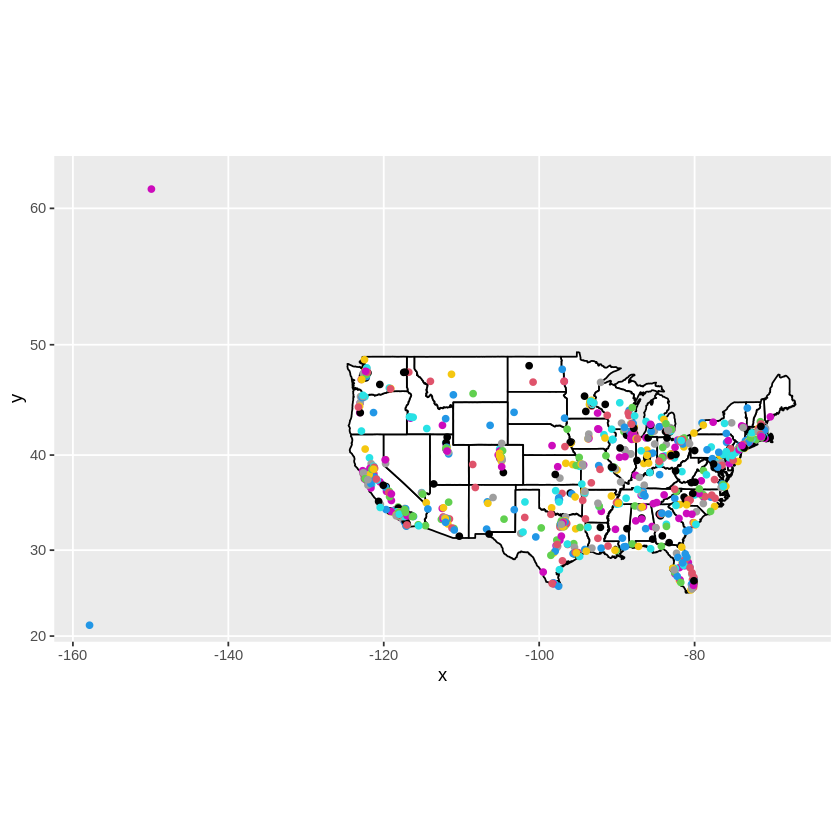

```r
#install.packages("ggmap")
#install.packages("maps")
#install.packages("mapproj")
#library(ggplot2)
#library(ggmap)
#library(maps)
#library(mapproj)
us <- map_data("state")
dfNew$state_name <- tolower(dfNew$state)
map <- ggplot(dfNew, aes(map_id=state_name))
map <- map + geom_map(map=us, fill="white", color="black")
map <- map + expand_limits(x=us$long, y=us$lat)
map <- map + coord_map()
map <- map + geom_point(aes(x=longitude,y=latitude), color=dfNew$population)
map
```

I) Add a block comment that criticizes the resulting map. It’s not very good.

```r
#There are a couple of things wrong with this graph, first the graph doesn't have any title or names for either of the axis that would help with understanding the graph or even a key to give information about what the points represent, next there are also a couple of points that are out of America which messes with The scale of everything
#I fixed my thing by doing color=dfNew$population which I really shouldn't have needed to do but it worked so I'll just go with it
```

## Step 4: Use aggregate() to make a dataframe of state-by-state population

Run the following lines of code to create a new data frame:

```r
dfSimple = aggregate(dfNew$rank, by = list(dfNew$state), FUN = length)
#makes it a from a dataframe with 1000 rows to a dataframe with 51, 1 for each state
dfSimple$name <- dfSimple$Group.1
#sets dfSimple$name to the contents of dfSimple$Group.1 which were all the state names (which I found out by calling it later in this cell)
dfSimple$Group.1 <- NULL
#gets rid of dfSimple$Group.1
dfSimple$numRankedCities <- dfSimple$x
#sets dfSimple$numRankedCities to the contents of dfSimple$x which were the number of cities in a state added together (which I found out by calling it later in this cell)
dfSimple$x <- NULL
#gets rid of dfSimple$x
dfSimple$name
#calls dfSimple$name
dfSimple$numRankedCities
#calls dfSimple$numRankedCities
```

1. 'Alabama'

2. 'Alaska'

3. 'Arizona'

4. 'Arkansas'

5. 'California'

6. 'Colorado'

7. 'Connecticut'

8. 'Delaware'

9. 'District of Columbia'

10. 'Florida'

11. 'Georgia'

12. 'Hawaii'

13. 'Idaho'

14. 'Illinois'

15. 'Indiana'

16. 'Iowa'

17. 'Kansas'

18. 'Kentucky'

19. 'Louisiana'

20. 'Maine'

21. 'Maryland'

22. 'Massachusetts'

23. 'Michigan'

24. 'Minnesota'

25. 'Mississippi'

26. 'Missouri'

27. 'Montana'

28. 'Nebraska'

29. 'Nevada'

30. 'New Hampshire'

31. 'New Jersey'

32. 'New Mexico'

33. 'New York'

34. 'North Carolina'

35. 'North Dakota'

36. 'Ohio'

37. 'Oklahoma'

38. 'Oregon'

39. 'Pennsylvania'

40. 'Rhode Island'

41. 'South Carolina'

42. 'South Dakota'

43. 'Tennessee'

44. 'Texas'

45. 'Utah'

46. 'Vermont'

47. 'Virginia'

48. 'Washington'

49. 'West Virginia'

50. 'Wisconsin'

51. 'Wyoming'

1. 12

2. 1

3. 25

4. 10

5. 212

6. 21

7. 15

8. 2

9. 1

10. 73

11. 18

12. 1

13. 8

14. 52

15. 21

16. 13

17. 11

18. 5

19. 9

20. 1

21. 7

22. 36

23. 31

24. 24

25. 6

26. 16

27. 4

28. 4

29. 6

30. 3

31. 22

32. 7

33. 17

34. 22

35. 4

36. 33

37. 11

38. 14

39. 13

40. 6

41. 12

42. 2

43. 17

44. 83

45. 19

46. 1

47. 17

48. 28

49. 2

50. 20

51. 2

J) Add a comment describing what each line of code does. Make sure to describe how many rows there are in **dfSimple** (and why there are that many rows).

```r
dfSimple
#51 rows for 51 states
```

A data.frame: 51 × 2

| name <chr> | numRankedCities <int> |
| --- | --- |
| Alabama | 12 |
| Alaska | 1 |
| Arizona | 25 |
| Arkansas | 10 |
| California | 212 |
| Colorado | 21 |
| Connecticut | 15 |
| Delaware | 2 |
| District of Columbia | 1 |
| Florida | 73 |
| Georgia | 18 |
| Hawaii | 1 |
| Idaho | 8 |
| Illinois | 52 |
| Indiana | 21 |
| Iowa | 13 |
| Kansas | 11 |
| Kentucky | 5 |
| Louisiana | 9 |
| Maine | 1 |
| Maryland | 7 |
| Massachusetts | 36 |
| Michigan | 31 |
| Minnesota | 24 |
| Mississippi | 6 |
| Missouri | 16 |
| Montana | 4 |
| Nebraska | 4 |
| Nevada | 6 |
| New Hampshire | 3 |
| New Jersey | 22 |
| New Mexico | 7 |
| New York | 17 |
| North Carolina | 22 |
| North Dakota | 4 |
| Ohio | 33 |
| Oklahoma | 11 |
| Oregon | 14 |
| Pennsylvania | 13 |
| Rhode Island | 6 |
| South Carolina | 12 |
| South Dakota | 2 |
| Tennessee | 17 |
| Texas | 83 |
| Utah | 19 |
| Vermont | 1 |
| Virginia | 17 |
| Washington | 28 |
| West Virginia | 2 |
| Wisconsin | 20 |
| Wyoming | 2 |

K) Name the most and least populous states in **dfSimple** and show the code you used to determine them.

```r
index1=1
index2=0
for (i in 1:51){
index2=index2+dfSimple$numRankedCities[i]
if(i==1){
vector<-as.character(sum(as.numeric(dfNew$population[index1:index2])))
}
else{
vector<-unique(c(vector, as.character(sum(as.numeric(dfNew$population[index1:index2])))))
   }
index1=index2+1
    }
dfSimple$population<-as.numeric(vector)
dfSimple$population
dfSimple$name[which.min(dfSimple$population)]
dfSimple$name[which.max(dfSimple$population)]
#I don't think I could explain why I did it like this if I tried because I did not make this code in any sort of linear format doing one step at a time instead I was just figuring out random errors as I went and trying to fix them and this was the code I got
#But I can tell you what this is doing, first it is making a vector of the added population of each City in each state and then it is For each of the 51 states and then it is making that into a new column in the dfSimple dataset
```

1. 1279813

2. 300950

3. 4691466

4. 787011

5. 27910620

6. 3012284

7. 1239817

8. 108891

9. 646449

10. 7410114

11. 1995615

12. 347884

13. 638333

14. 6055539

15. 2393472

16. 1037690

17. 1327215

18. 1079181

19. 1238263

20. 66318

21. 954852

22. 3007084

23. 2979267

24. 2055749

25. 427944

26. 1843953

27. 277392

28. 807304

29. 1481832

30. 239934

31. 1859793

32. 953296

33. 9933332

34. 3358746

35. 281945

36. 3480839

37. 1666530

38. 1680656

39. 2598080

40. 499878

41. 812734

42. 235488

43. 2483464

44. 14836230

45. 1440569

46. 42284

47. 2236964

48. 2956938

49. 99998

50. 1910367

51. 122076

'Vermont'

'California'

## Step 5: Use ggplot and ggmap to shade a map of the U.S. with state population

L) Copy the ggplot code from Step 3. In the initial ggplot statement, you will need to use your new dataframe, so substitute **dfSimple** in place of **dfNew**. Additionally, instead of using **geom_point** to plot points, use this aesthetic to fill the polygons with a **color** for each state. Make sure to expand the limits correctly and that you have used **coord_map** appropriately.

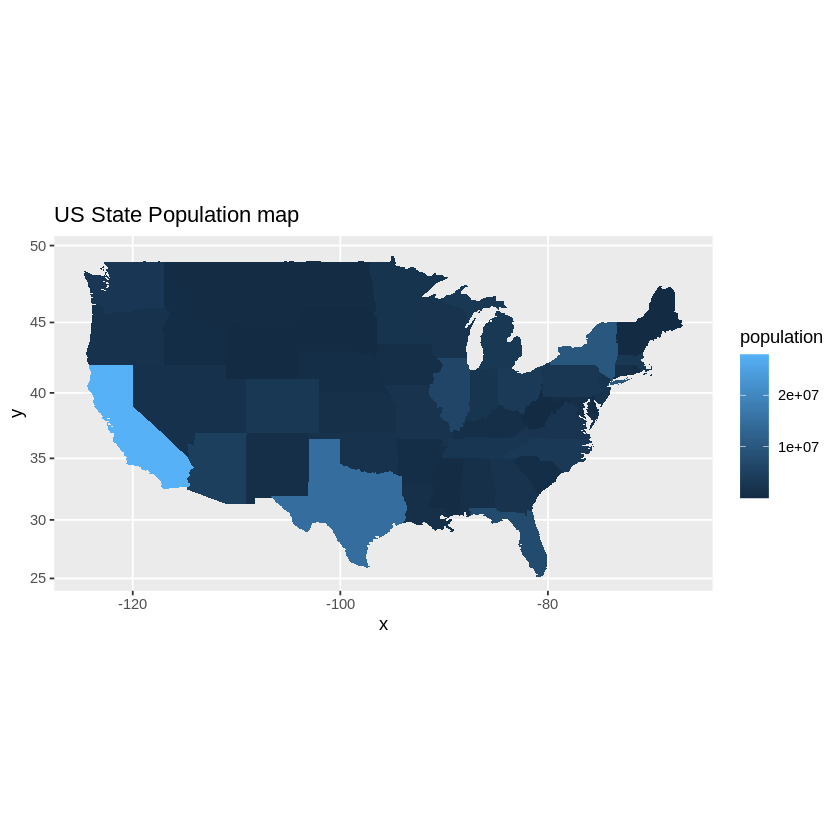

```r
dfSimple$name <- tolower(dfSimple$name)
map_new <- ggplot(dfSimple, aes(map_id=name))
map_new <- map_new + geom_map(map=us, aes(fill=population))
map_new <- map_new + expand_limits(x=us$long, y=us$lat)
map_new <- map_new + coord_map() + ggtitle("US State Population map")
map_new
```